# homework_yy_oringinal-Copy2

## Problem 2 Further Image Manipulation (7pts)

In this problem you will solve a jigsaw puzzle using the 'jigsaw.png' provided with the homework. The solution of this jigsaw is the Lenna image we used above. There are a total of 16 jigsaw pieces of size 128x128x3 which together make up the 512x512x3 image. Not only is Lemma jumbled spatially, but some of the channels in jigsaw pieces are also permuted i.e. **RGB** to **BGR** and **GRB**.

Your task is to put all the pieces to their respective locations and correct the channel permutations. To achieve this task, you are required to complete the three helper functions that will be used to solve this puzzle. You are **NOT** allowed to use any function other than the three provided here. Also, the code needs to be *vectorised* i.e. you are **NOT** allowed to use *for* loops to achieve this task.

```
Jigsaw Puzzle
```

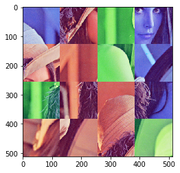

```
Solution
```

[figure not shown]

```python
def getTile(jigsaw, tile_idx):

    '''
    This function returns a particular jigsaw piece

    jigsaw      : 512x512x3 np.ndarray
    tile_idx : tuple containing the (i,j) location of the piece

    piece    : 128x128x3 np.ndarray
    '''
    assert isinstance(tile_idx,tuple), 'tile index must be a tuple'
    assert len(tile_idx) == 2, 'tile index must specify the row and column index of the jigsaw'


    # Write your code here
    piece = np.zeros((128,128,3))   # modify piece
    piece = jigsaw[tile_idx[0]*128: (tile_idx[0]+1)*128, tile_idx[1]*128: (tile_idx[1]+1)*128,:3]

    return piece.copy()

def permuteChannels(tile, permutation):

    '''
    This function performs a permutation on channel

    tile          : 128x128x3 np.ndarray
    permutation   : tuple containing (i,j,k) channel indices
    tile_permuted : 128x128x3 np.ndarray
    '''

    assert tile.shape == (128,128,3), 'tile size should be 128x128x3'
    assert isinstance(permutation, tuple), 'permutation should be a tuple'
    assert len(permutation) == 3, 'There are only 3 channels'

    #Write your code here
    tile[:,:,[permutation[0],permutation[1],permutation[2]]]=tile[:,:,[0,1,2]]
    tile_permuted = tile.copy()

    return tile_permuted.copy()

def putTile(board, tile, tile_idx):

    '''
    This function put a jigsaw piece at a particular location on the board

    board : 512x512x3 np.ndarray
    tile : 128x128x3 np.ndarray
    tile_idx : tuple containing the (i,j) location of the piece
    img : 512x512x3 np.ndarray
    '''

    assert board.shape == (512,512,3), 'canvas size should be 512x512x3'
    assert tile.shape == (128,128,3), 'tile size should be 128x128x3'
    assert isinstance(tile_idx,tuple), 'tile index must be a tuple'
    assert len(tile_idx) == 2, 'tile index must specify the row and column index of the jigsaw'

    # Write your own code here
    img = board.copy()   # modify img
    img[tile_idx[0]*128:(1+tile_idx[0])*128, tile_idx[1]*128:(1+tile_idx[1])*128, 0:] = tile

    return img

TILE_SIZE = 128
source = [(0,0),(0,1),(0,2),(0,3),
          (1,0),(1,1),(1,2),(1,3),
          (2,0),(2,1),(2,2),(2,3),
          (3,0),(3,1),(3,2),(3,3)]

# Fill in the target list with the corresponding piece locations
target = [(0,2),(2,1),(1,0),(2,2),
          (1,2),(0,0),(3,2),(0,3),
          (2,0),(3,0),(0,1),(3,1),
          (3,3),(1,3),(1,1),(2,3)]

#Fill in the respective channel permutations
channelPermutation = [(2,1,0),(0,1,2),(1,0,2),(2,1,0),
                      (0,1,2),(0,1,2),(1,0,2),(2,1,0),
                      (1,0,2),(0,1,2),(0,1,2),(2,1,0),
                      (0,1,2),(0,1,2),(0,1,2),(1,0,2)]

jigsaw = plt.imread('jigsaw.png')
board = np.ones(jigsaw.shape)

for i in range(16):
    tile = getTile(jigsaw, source[i])
    tile = permuteChannels(tile, channelPermutation[i])
    board = putTile(board, tile, target[i])

print("Jigsaw Puzzle")
plt.imshow(jigsaw)
plt.show()
print("Solution")
plt.imshow(board)
plt.show()
```

**Submission Instructions**  
Remember to submit a pdf version of this notebook to Gradescope. You can find the export option at File $\rightarrow$ Download as $\rightarrow$ PDF via Latex. Upload to Gradescope. **NOTE**: You need to have XeTex installed on your machine to generate PDFs